# **Exploring Population Structure**

# Introduction

In this short workbook, we outline how using R we can visualise and explore the various ways to understand the structure and growth of the Palauan population. The data source is the Demographic Statistics Database of UNData. What we aim to do is compute the growth rates and visualise the changing population pyramid.

# Loading Packages

```r
library(tidyverse)
library(gganimate)
library(gt)
library(ggthemes)
library(plotly)
```

# Calculating Growth rate

Output full pop structure data for each census year from 1958 to present

```r
# load raw population tables
population_data = read_csv("data/pop_structure.csv") %>%
  as_tibble()

# output table
population_data %>%
  gt() %>%
  tab_options(ihtml.active = TRUE,
              ihtml.use_page_size_select = TRUE)
```

| Country or Area | Year | Area | Sex | Age | Record Type | Source Year | Value |
| --- | --- | --- | --- | --- | --- | --- | --- |
| Palau | 1958 | Total | Female | 00 to 04 | Census - de facto - complete tabulation | 2000 | 722 |
| Palau | 1958 | Total | Female | 05 to 09 | Census - de facto - complete tabulation | 2000 | 699 |
| Palau | 1958 | Total | Female | 10 to 14 | Census - de facto - complete tabulation | 2000 | 445 |
| Palau | 1958 | Total | Female | 15 to 19 | Census - de facto - complete tabulation | 2000 | 472 |
| Palau | 1958 | Total | Female | 20 to 24 | Census - de facto - complete tabulation | 2000 | 357 |
| Palau | 1958 | Total | Female | 25 to 29 | Census - de facto - complete tabulation | 2000 | 260 |
| Palau | 1958 | Total | Female | 30 to 34 | Census - de facto - complete tabulation | 2000 | 277 |
| Palau | 1958 | Total | Female | 35 to 39 | Census - de facto - complete tabulation | 2000 | 218 |
| Palau | 1958 | Total | Female | 40 to 44 | Census - de facto - complete tabulation | 2000 | 228 |
| Palau | 1958 | Total | Female | 45 to 49 | Census - de facto - complete tabulation | 2000 | 146 |

[output cut: 406 more lines]

## Year Totals

Determine to yearly totals of population from the census for each year

```r
# use groupby() to calculate year totals of pop
pop_size = population_data %>%
  group_by(Year) %>%
  summarise(Value = sum(Value))
```

### Total Population of Palau by Year of Census

```r
# output table
pop_size %>%
  gt() %>%
  tab_style(style = cell_fill(color = "#1F78B4"),
            locations = cells_column_labels(columns = 1:2))
```

| Year | Value |
| --- | --- |
| 1958 | 8884 |
| 1967 | 10972 |
| 1970 | 11210 |
| 1973 | 12630 |
| 1980 | 12116 |
| 1986 | 13873 |
| 1990 | 15122 |
| 1995 | 17225 |
| 2000 | 19042 |
| 2005 | 20096 |
| 2012 | 17501 |
| 2015 | 17661 |
| 2020 | 17614 |

## Growth Rate Calculations

Calculate the Instantous Growth Rate using natural logs

```r
# create new data frame to track intervals
growth_rates = data.frame(
  StartYear = pop_size$Year[-length(pop_size$Year)],
  EndYear = pop_size$Year[-1],
  StartYearPop = pop_size$Value[-length(pop_size$Value)],
  EndYearPop = pop_size$Value[-1]
)

# calculate yearly crude growth rate
growth_rates$GrowthRate = round(log(growth_rates$EndYearPop /
                                      growth_rates$StartYearPop) /
                                  (growth_rates$EndYear - growth_rates$StartYear) * 100, 2)
```

### Annualised IGR for Palau by Census Year

```r
# output table
growth_rates %>%
  gt() %>%
  tab_style(style = cell_fill(color = "#1F78B4"),
            locations = cells_column_labels(columns = 1:5))
```

| StartYear | EndYear | StartYearPop | EndYearPop | GrowthRate |
| --- | --- | --- | --- | --- |
| 1958 | 1967 | 8884 | 10972 | 2.35 |
| 1967 | 1970 | 10972 | 11210 | 0.72 |
| 1970 | 1973 | 11210 | 12630 | 3.98 |
| 1973 | 1980 | 12630 | 12116 | -0.59 |
| 1980 | 1986 | 12116 | 13873 | 2.26 |
| 1986 | 1990 | 13873 | 15122 | 2.16 |
| 1990 | 1995 | 15122 | 17225 | 2.60 |
| 1995 | 2000 | 17225 | 19042 | 2.01 |
| 2000 | 2005 | 19042 | 20096 | 1.08 |
| 2005 | 2012 | 20096 | 17501 | -1.98 |
| 2012 | 2015 | 17501 | 17661 | 0.30 |
| 2015 | 2020 | 17661 | 17614 | -0.05 |

# Doubling / Halving Time

Use a for loop to determine whether to growth rate is positive or negative, and calculate doubling or halving time as such

```r
growth_rates$DoublingTime = NA  # fill "DoublingTime" column with na
growth_rates$HalvingTime = NA   # fill "HalvingTime" column with na

# calculate "DoublingTime" and "HalvingTime" based on "GrowthRate"
for (i in 1:nrow(growth_rates)) { # do this for every roe
  gr = growth_rates$GrowthRate[i]

  # calculate "DoublingTime" for positive growth rates
  if (gr > 0) {
    growth_rates$DoublingTime[i] = round(log(2) / (gr / 100), 2)
  }

  # calculate "HalvingTime" for negative growth rates
  if (gr < 0) {
    growth_rates$HalvingTime[i] = round(log(0.5) / (gr / 100), 2)
  }
}
```

### Doubling/Halving Time of the Palau Population by Census Year

```r
# output results
growth_rates %>%
  gt() %>%
  tab_style(style = cell_fill(color = "#1F78B4"),
            locations = cells_column_labels(columns = 1:7))
```

| StartYear | EndYear | StartYearPop | EndYearPop | GrowthRate | DoublingTime | HalvingTime |
| --- | --- | --- | --- | --- | --- | --- |
| 1958 | 1967 | 8884 | 10972 | 2.35 | 29.50 | NA |
| 1967 | 1970 | 10972 | 11210 | 0.72 | 96.27 | NA |
| 1970 | 1973 | 11210 | 12630 | 3.98 | 17.42 | NA |
| 1973 | 1980 | 12630 | 12116 | -0.59 | NA | 117.48 |
| 1980 | 1986 | 12116 | 13873 | 2.26 | 30.67 | NA |
| 1986 | 1990 | 13873 | 15122 | 2.16 | 32.09 | NA |
| 1990 | 1995 | 15122 | 17225 | 2.60 | 26.66 | NA |
| 1995 | 2000 | 17225 | 19042 | 2.01 | 34.48 | NA |
| 2000 | 2005 | 19042 | 20096 | 1.08 | 64.18 | NA |
| 2005 | 2012 | 20096 | 17501 | -1.98 | NA | 35.01 |
| 2012 | 2015 | 17501 | 17661 | 0.30 | 231.05 | NA |
| 2015 | 2020 | 17661 | 17614 | -0.05 | NA | 1386.29 |

# Dependency Ratio

Set different age categories and use this to label rows to then compute various dependency ratios.

```r
# define the vector of working age groups
working_age = c("20 to 24",
                "25 to 29",
                "30 to 34",
                "35 to 39",
                "40 to 44",
                "45 to 49",
                "50 to 54",
                "55 to 59",
                "60 to 64")

# define the vector of youth age groups
youth_age = c("00 to 04",
              "05 to 09",
              "10 to 14",
              "15 to 19")

# define the vector of old age groups
old_age = c("65 to 69",
            "70 to 74",
            "75 plus")

# calculate the youth dependency ratio
youth_dependency = population_data %>%
  group_by(Year) %>%
  summarize(YDR = sum(Value[Age %in% youth_age]) /
              sum(Value[Age %in% working_age]))


# calculate the old age dependency ratio
old_age_dependency = population_data %>%
  group_by(Year) %>%
  summarize(ODR = sum(Value[Age %in% old_age]) /
              sum(Value[Age %in% working_age]))

# calculate the total dependency ratio, could also just add the last two lol
total_dependency = population_data %>%
  group_by(Year) %>%
  summarize(TDR = sum(Value[Age %in% youth_age | Age %in% old_age]) /
              sum(Value[Age %in% working_age]))

# merge the results into one dataframe
dependency_ratios = youth_dependency %>%
  left_join(old_age_dependency, by = "Year") %>%
  left_join(total_dependency, by = "Year")

# create function to round all numeric variables
round_df = function(x, digits) {
  # x is the data frame
  # digits is number of digits to round
  numeric_columns = sapply(x, mode) == 'numeric'
  x[numeric_columns] = round(x[numeric_columns], digits)
  x
}
```

### Dependency Ratios for Palau by Census Year

```r
# output results
round_df(dependency_ratios, 2) %>%
  gt() %>%
  tab_style(style = cell_fill(color = "#1F78B4"),
            locations = cells_column_labels(columns = 1:4))
```

| Year | YDR | ODR | TDR |
| --- | --- | --- | --- |
| 1958 | 1.37 | 0.13 | 1.50 |
| 1967 | 1.88 | 0.15 | 2.03 |
| 1970 | 1.58 | 0.12 | 1.70 |
| 1973 | 1.53 | 0.13 | 1.66 |
| 1980 | 1.26 | 0.13 | 1.39 |
| 1986 | 0.94 | 0.11 | 1.05 |
| 1990 | 0.74 | 0.11 | 0.85 |
| 1995 | 0.60 | 0.10 | 0.70 |
| 2000 | 0.47 | 0.09 | 0.57 |
| 2005 | 0.50 | 0.11 | 0.61 |
| 2012 | 0.44 | 0.10 | 0.54 |
| 2015 | 0.42 | 0.11 | 0.53 |
| 2020 | 0.38 | 0.15 | 0.53 |

# Median Age

Calculate the median age through mapping on mid points and calculating a weighted mean

```r
# set mid points for age
age_mapping = c(
  "00 to 04" = 2,
  "05 to 09" = 7,
  "10 to 14" = 12,
  "15 to 19" = 17,
  "20 to 24" = 22,
  "25 to 29" = 27,
  "30 to 34" = 32,
  "35 to 39" = 37,
  "40 to 44" = 42,
  "45 to 49" = 47,
  "50 to 54" = 52,
  "55 to 59" = 57,
  "60 to 64" = 62,
  "65 to 69" = 67,
  "70 to 74" = 72,
  "75 plus" = 80
)

# calculate median
median_age_data = population_data %>%
  mutate(Numeric_Age = age_mapping[Age]) %>%
  filter(!is.na(Numeric_Age)) %>%
  group_by(Year) %>%
  summarize(Median_Age = weighted.mean(Numeric_Age,
                                       Value, na.rm = TRUE))
```

### Palau Median Age by Census Year

```r
# output results
round_df(median_age_data, 2) %>%
  gt() %>%
  tab_style(style = cell_fill(color = "#1F78B4"),
            locations = cells_column_labels(columns = 1:2))
```

| Year | Median_Age |
| --- | --- |
| 1958 | 23.09 |
| 1967 | 21.71 |
| 1970 | 22.47 |
| 1973 | 22.58 |
| 1980 | 24.44 |
| 1986 | 25.82 |
| 1990 | 27.89 |
| 1995 | 28.86 |
| 2000 | 31.34 |
| 2005 | 32.29 |
| 2012 | 34.31 |
| 2015 | 34.90 |
| 2020 | 36.84 |

# Population Pyramids

Wrangle the data to be fit for plotting into population pyramids

```r
# two easy joins
population_data = left_join(population_data,
                            median_age_data,
                            by = ("Year" = "Year"))

population_data = left_join(population_data,
                            dependency_ratios,
                            by = ("Year" = "Year"))

# strip back growth rate df
growth_rates$Year = growth_rates$EndYear
growth_rates$Total_Pop = growth_rates$EndYearPop
growth_rates_simp = growth_rates %>%
  select(Year, Total_Pop, GrowthRate)

# add info for 1958
start_year_info = growth_rates[growth_rates$StartYear == 1958, ]
start_year_info$Year = start_year_info$StartYear
start_year_info = start_year_info %>%
  select(Year, Total_Pop)
start_year_info$GrowthRate = NA
growth_rates_simp = rbind(growth_rates_simp, start_year_info)

# join
population_data = left_join(population_data,
                            growth_rates_simp,
                            by = ("Year" = "Year"))
```

### Animated Population Pyramid

Using gganimate make an animated gif of the population development

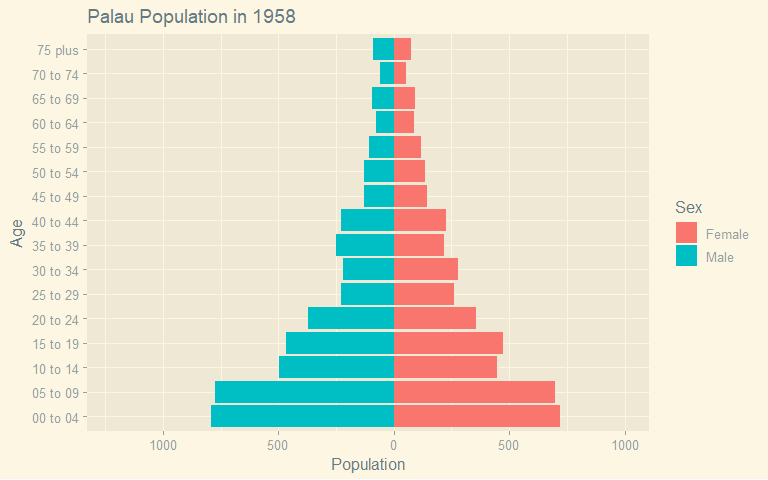

```r
# create ggplot object
pop = ggplot(data = population_data, aes(
  x = as.factor(Age),
  y = ifelse(Sex == "Male",-Value, Value),
  fill = as.factor(Sex))) +
  geom_col(aes(group = as.factor(Age))) +
  coord_flip() +
  xlab("Age") +
  ylab("Population") +
  # get rid of the male negative effect
  scale_y_continuous(labels = abs) +
  theme_solarized_2() +
  # set "Year" as the transition state
  transition_states(Year, transition_length = 2, state_length = 1) +
  labs(title = 'Palau Population in {closest_state}',
       fill= "Sex") +
  ease_aes('linear')

# save animation
anim_pop = animate(pop)
anim_save(animation = anim_pop, filename ="pop_pyramid.gif")
```

### Making a Static Plot for each Year

Also output a static png for each year using a for loop. Add in the data on the dependency ratios and median age into subtitles.

```r
# loop through each unique year
for (year in unique(population_data$Year)) {
  # filter data for the current year
  year_data = subset(population_data, Year == year)
  title = paste('Palau Population in', unique(year_data$Year))
  subtitle = paste("Total Population:",
                    unique(year_data$Total_Pop),
                   ", YDR:", round(
                    unique(year_data$YDR), 2),
                   ", ODR:", round(
                    unique(year_data$ODR), 2),
                   ", TDR:", round(
                    unique(year_data$TDR), 2),
                   ", Median Age:", round(
                    unique(year_data$Median_Age), 2),
                   ", Growth Rate:", round(
                    unique(year_data$GrowthRate), 2))

  # create the population pyramid plot for the current year
  population_plot = ggplot(year_data, aes(
    x = as.factor(Age),
    y = ifelse(Sex == "Male",-Value, Value),
    fill = as.factor(Sex))) +
    geom_col(aes(group = as.factor(Age))) +
    coord_flip() +
    xlab("Age") +
    ylab("Population") +
    labs(title = title,
         subtitle = subtitle,
         fill= "Sex") +
    # get rid of the male negative effect
    scale_y_continuous(labels = abs,
                       limits = c(-1500, 1500)) +
    theme_solarized_2()

  # save the plot as a .png file with the year in the filename
  filename = paste("pop_pyramid_", year, ".png", sep = "")
  ggsave(filename, plot = population_plot, width = 10, height = 10)
}
```